# Risk Factor Analysis

## Outcome Variable

**Outcome Variable:** stunted

## Predictor Variables

**Intervention Variable:** tr

**Adjustment Set:**

unadjusted

## Stratifying Variables

The analysis was stratified on these variable(s):

- hdlvry
- agecat
- studyid
- country

## Data Summary

| hdlvry | agecat | studyid | country | tr | stunted | n_cell | n |
| --- | --- | --- | --- | --- | --- | --- | --- |
| 1 | Birth | ki1000125-AgaKhanUniv | PAKISTAN | Control | 0 | 6 | 10 |
| 1 | Birth | ki1000125-AgaKhanUniv | PAKISTAN | Maternal | 0 | 4 | 10 |
| 1 | 6 months | ki1000125-AgaKhanUniv | PAKISTAN | Control | 0 | 121 | 341 |
| 1 | 6 months | ki1000125-AgaKhanUniv | PAKISTAN | Control | 1 | 62 | 341 |
| 1 | 6 months | ki1000125-AgaKhanUniv | PAKISTAN | Maternal | 0 | 127 | 341 |
| 1 | 6 months | ki1000125-AgaKhanUniv | PAKISTAN | Maternal | 1 | 31 | 341 |
| 0 | 6 months | ki1000125-AgaKhanUniv | PAKISTAN | Control | 0 | 65 | 176 |
| 0 | 6 months | ki1000125-AgaKhanUniv | PAKISTAN | Control | 1 | 25 | 176 |
| 0 | 6 months | ki1000125-AgaKhanUniv | PAKISTAN | Maternal | 0 | 60 | 176 |
| 0 | 6 months | ki1000125-AgaKhanUniv | PAKISTAN | Maternal | 1 | 26 | 176 |
| 0 | Birth | ki1000125-AgaKhanUniv | PAKISTAN | Control | 0 | 1 | 1 |
| 0 | 6 months | ki1000304-ZnMort | INDIA | Control | 0 | 26 | 67 |
| 0 | 6 months | ki1000304-ZnMort | INDIA | Control | 1 | 15 | 67 |
| 0 | 6 months | ki1000304-ZnMort | INDIA | Zinc | 0 | 17 | 67 |
| 0 | 6 months | ki1000304-ZnMort | INDIA | Zinc | 1 | 9 | 67 |
| 0 | 24 months | ki1000304-ZnMort | INDIA | Control | 0 | 16 | 66 |
| 0 | 24 months | ki1000304-ZnMort | INDIA | Control | 1 | 20 | 66 |
| 0 | 24 months | ki1000304-ZnMort | INDIA | Zinc | 0 | 21 | 66 |
| 0 | 24 months | ki1000304-ZnMort | INDIA | Zinc | 1 | 9 | 66 |
| 1 | 24 months | ki1000304-ZnMort | INDIA | Control | 0 | 11 | 74 |
| 1 | 24 months | ki1000304-ZnMort | INDIA | Control | 1 | 28 | 74 |
| 1 | 24 months | ki1000304-ZnMort | INDIA | Zinc | 0 | 9 | 74 |
| 1 | 24 months | ki1000304-ZnMort | INDIA | Zinc | 1 | 26 | 74 |
| 1 | 6 months | ki1000304-ZnMort | INDIA | Control | 0 | 29 | 78 |
| 1 | 6 months | ki1000304-ZnMort | INDIA | Control | 1 | 16 | 78 |
| 1 | 6 months | ki1000304-ZnMort | INDIA | Zinc | 0 | 21 | 78 |
| 1 | 6 months | ki1000304-ZnMort | INDIA | Zinc | 1 | 12 | 78 |
| 1 | 6 months | ki1000304b-SAS-CompFeed | INDIA | Control | 0 | 140 | 424 |
| 1 | 6 months | ki1000304b-SAS-CompFeed | INDIA | Control | 1 | 55 | 424 |
| 1 | 6 months | ki1000304b-SAS-CompFeed | INDIA | Other | 0 | 155 | 424 |

[output cut: 130 more lines]

The following strata were considered:

- hdlvry: 0, agecat: 24 months, studyid: iLiNS_DYADM_LNS, country: MALAWI
- hdlvry: 0, agecat: 24 months, studyid: ki1000304-ZnMort, country: INDIA
- hdlvry: 0, agecat: 24 months, studyid: ki1017093b-PROVIDE, country: BANGLADESH
- hdlvry: 0, agecat: 24 months, studyid: ki1066203-TanzaniaChild2, country: TANZANIA, UNITED REPUBLIC OF
- hdlvry: 0, agecat: 24 months, studyid: ki1148112-iLiNS-DYAD-M, country: MALAWI
- hdlvry: 0, agecat: 24 months, studyid: kiGH5241-JiVitA-3, country: BANGLADESH
- hdlvry: 0, agecat: 24 months, studyid: kiGH5241-JiVitA-4, country: BANGLADESH
- hdlvry: 0, agecat: 6 months, studyid: iLiNS_DYADM_LNS, country: MALAWI
- hdlvry: 0, agecat: 6 months, studyid: ki1000125-AgaKhanUniv, country: PAKISTAN
- hdlvry: 0, agecat: 6 months, studyid: ki1000304-ZnMort, country: INDIA
- hdlvry: 0, agecat: 6 months, studyid: ki1000304b-SAS-CompFeed, country: INDIA
- hdlvry: 0, agecat: 6 months, studyid: ki1000304b-SAS-FoodSuppl, country: INDIA
- hdlvry: 0, agecat: 6 months, studyid: ki1017093b-PROVIDE, country: BANGLADESH
- hdlvry: 0, agecat: 6 months, studyid: ki1066203-TanzaniaChild2, country: TANZANIA, UNITED REPUBLIC OF
- hdlvry: 0, agecat: 6 months, studyid: ki1148112-iLiNS-DYAD-M, country: MALAWI
- hdlvry: 0, agecat: 6 months, studyid: kiGH5241-JiVitA-3, country: BANGLADESH
- hdlvry: 0, agecat: 6 months, studyid: kiGH5241-JiVitA-4, country: BANGLADESH
- hdlvry: 0, agecat: Birth, studyid: iLiNS_DYADM_LNS, country: MALAWI
- hdlvry: 0, agecat: Birth, studyid: ki1000125-AgaKhanUniv, country: PAKISTAN
- hdlvry: 0, agecat: Birth, studyid: ki1000304b-SAS-CompFeed, country: INDIA
- hdlvry: 0, agecat: Birth, studyid: ki1148112-iLiNS-DYAD-M, country: MALAWI
- hdlvry: 0, agecat: Birth, studyid: kiGH5241-JiVitA-3, country: BANGLADESH
- hdlvry: 0, agecat: Birth, studyid: kiGH5241-JiVitA-4, country: BANGLADESH
- hdlvry: 1, agecat: 24 months, studyid: iLiNS_DYADM_LNS, country: MALAWI
- hdlvry: 1, agecat: 24 months, studyid: ki1000304-ZnMort, country: INDIA
- hdlvry: 1, agecat: 24 months, studyid: ki1148112-iLiNS-DYAD-M, country: MALAWI
- hdlvry: 1, agecat: 24 months, studyid: kiGH5241-JiVitA-4, country: BANGLADESH
- hdlvry: 1, agecat: 6 months, studyid: iLiNS_DYADM_LNS, country: MALAWI
- hdlvry: 1, agecat: 6 months, studyid: ki1000125-AgaKhanUniv, country: PAKISTAN
- hdlvry: 1, agecat: 6 months, studyid: ki1000304-ZnMort, country: INDIA
- hdlvry: 1, agecat: 6 months, studyid: ki1000304b-SAS-CompFeed, country: INDIA
- hdlvry: 1, agecat: 6 months, studyid: ki1000304b-SAS-FoodSuppl, country: INDIA
- hdlvry: 1, agecat: 6 months, studyid: ki1017093b-PROVIDE, country: BANGLADESH
- hdlvry: 1, agecat: 6 months, studyid: ki1066203-TanzaniaChild2, country: TANZANIA, UNITED REPUBLIC OF
- hdlvry: 1, agecat: 6 months, studyid: ki1148112-iLiNS-DYAD-M, country: MALAWI
- hdlvry: 1, agecat: 6 months, studyid: kiGH5241-JiVitA-3, country: BANGLADESH
- hdlvry: 1, agecat: 6 months, studyid: kiGH5241-JiVitA-4, country: BANGLADESH
- hdlvry: 1, agecat: Birth, studyid: ki1000125-AgaKhanUniv, country: PAKISTAN
- hdlvry: 1, agecat: Birth, studyid: ki1000304b-SAS-CompFeed, country: INDIA
- hdlvry: 1, agecat: Birth, studyid: kiGH5241-JiVitA-3, country: BANGLADESH
- hdlvry: 1, agecat: Birth, studyid: kiGH5241-JiVitA-4, country: BANGLADESH

### Dropped Strata

Some strata were dropped due to rare outcomes:

- hdlvry: 1, agecat: Birth, studyid: ki1000125-AgaKhanUniv, country: PAKISTAN
- hdlvry: 0, agecat: Birth, studyid: ki1000125-AgaKhanUniv, country: PAKISTAN
- hdlvry: 0, agecat: 6 months, studyid: ki1000304b-SAS-CompFeed, country: INDIA
- hdlvry: 0, agecat: Birth, studyid: ki1000304b-SAS-CompFeed, country: INDIA
- hdlvry: 0, agecat: 6 months, studyid: ki1017093b-PROVIDE, country: BANGLADESH
- hdlvry: 1, agecat: 6 months, studyid: ki1017093b-PROVIDE, country: BANGLADESH
- hdlvry: 0, agecat: 24 months, studyid: ki1017093b-PROVIDE, country: BANGLADESH
- hdlvry: 1, agecat: 6 months, studyid: ki1066203-TanzaniaChild2, country: TANZANIA, UNITED REPUBLIC OF
- hdlvry: 0, agecat: 24 months, studyid: ki1066203-TanzaniaChild2, country: TANZANIA, UNITED REPUBLIC OF
- hdlvry: 0, agecat: Birth, studyid: ki1148112-iLiNS-DYAD-M, country: MALAWI
- hdlvry: 0, agecat: 24 months, studyid: ki1148112-iLiNS-DYAD-M, country: MALAWI
- hdlvry: 1, agecat: 24 months, studyid: ki1148112-iLiNS-DYAD-M, country: MALAWI
- hdlvry: 0, agecat: 6 months, studyid: kiGH5241-JiVitA-3, country: BANGLADESH
- hdlvry: 0, agecat: 24 months, studyid: kiGH5241-JiVitA-3, country: BANGLADESH
- hdlvry: 0, agecat: Birth, studyid: kiGH5241-JiVitA-3, country: BANGLADESH
- hdlvry: 0, agecat: Birth, studyid: kiGH5241-JiVitA-4, country: BANGLADESH
- hdlvry: 0, agecat: Birth, studyid: iLiNS_DYADM_LNS, country: MALAWI
- hdlvry: 0, agecat: 24 months, studyid: iLiNS_DYADM_LNS, country: MALAWI
- hdlvry: 1, agecat: 6 months, studyid: iLiNS_DYADM_LNS, country: MALAWI
- hdlvry: 1, agecat: 24 months, studyid: iLiNS_DYADM_LNS, country: MALAWI

## Methods Detail

We’re interested in the causal parameters $E[Y_a]$ for all values of $a \in \mathcal{A}$. These parameters represent the mean outcome if, possibly contrary to fact, we intervened to set all units to have $A=a$. Under the randomization and positivity assumptions, these are identified by the statistical parameters $\psi_a=E_W[E_{Y|A,W}(Y|A=a,W)]$. In addition, we’re interested in the mean of $Y$, $E[Y]$ under no intervention (the observed mean). We will estimate these parameters by using SuperLearner to fit the relevant likelihood factors – $E_{Y|A,W}(Y|A=a,W)$ and $p(A=a|W)$, and then updating our likelihood fit using a joint TMLE.

For unadjusted analyses ($W=\{\}$), initial likelihoods were estimated using Lrnr_glm to estimate the simple $E(Y|A)$ and Lrnr_mean to estimate $p(A)$. For adjusted analyses, a small library containing Lrnr_glmnet, Lrnr_xgboost, and Lrnr_mean was used.

Having estimated these parameters, we will then use the delta method to estimate relative risks and attributable risks relative to a prespecified baseline level of $A$.

# Results Detail

## Results Plots

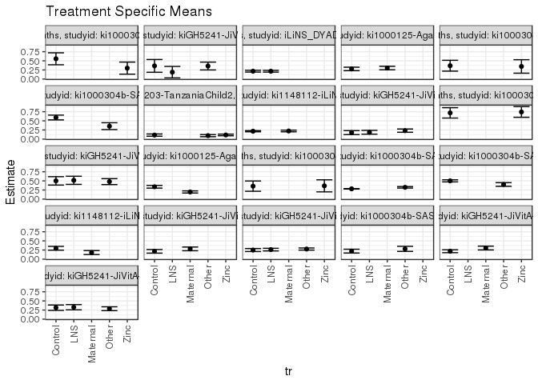

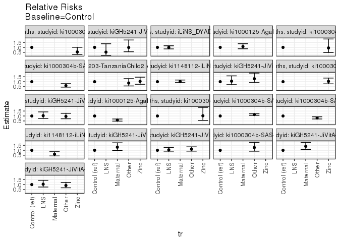

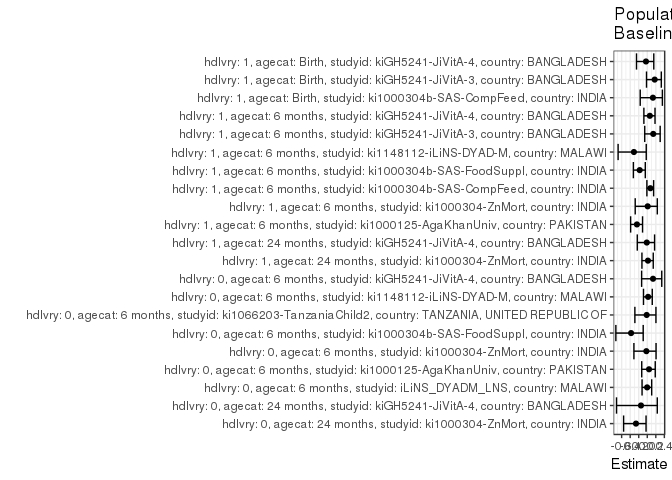

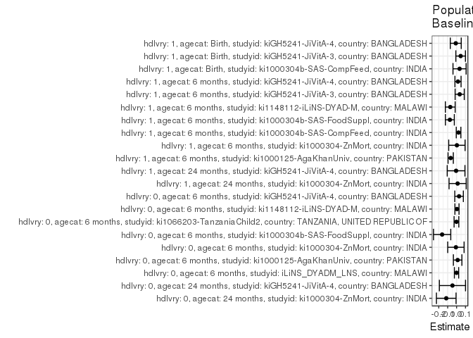

## Results Table

### Parameter: TSM

| hdlvry | agecat | studyid | country | intervention_level | baseline_level | estimate | ci_lower | ci_upper |
| --- | --- | --- | --- | --- | --- | --- | --- | --- |
| 0 | 6 months | iLiNS_DYADM_LNS | MALAWI | Control | NA | 0.2158273 | 0.1920956 | 0.2395591 |
| 0 | 6 months | iLiNS_DYADM_LNS | MALAWI | LNS | NA | 0.2145329 | 0.1903889 | 0.2386768 |
| 0 | 6 months | ki1000125-AgaKhanUniv | PAKISTAN | Control | NA | 0.2777778 | 0.2303232 | 0.3252324 |
| 0 | 6 months | ki1000125-AgaKhanUniv | PAKISTAN | Maternal | NA | 0.3023256 | 0.2547608 | 0.3498904 |
| 0 | 6 months | ki1000304-ZnMort | INDIA | Control | NA | 0.3658537 | 0.2173046 | 0.5144028 |
| 0 | 6 months | ki1000304-ZnMort | INDIA | Zinc | NA | 0.3461538 | 0.1619074 | 0.5304003 |
| 0 | 6 months | ki1000304b-SAS-FoodSuppl | INDIA | Control | NA | 0.5909091 | 0.5258727 | 0.6559454 |
| 0 | 6 months | ki1000304b-SAS-FoodSuppl | INDIA | Other | NA | 0.3541667 | 0.2607210 | 0.4476123 |
| 0 | 6 months | ki1066203-TanzaniaChild2 | TANZANIA, UNITED REPUBLIC OF | Control | NA | 0.1100000 | 0.0793278 | 0.1406722 |
| 0 | 6 months | ki1066203-TanzaniaChild2 | TANZANIA, UNITED REPUBLIC OF | Other | NA | 0.0951157 | 0.0659527 | 0.1242787 |
| 0 | 6 months | ki1066203-TanzaniaChild2 | TANZANIA, UNITED REPUBLIC OF | Zinc | NA | 0.1141439 | 0.0921843 | 0.1361035 |
| 0 | 6 months | ki1148112-iLiNS-DYAD-M | MALAWI | Control | NA | 0.2158273 | 0.1999078 | 0.2317469 |
| 0 | 6 months | ki1148112-iLiNS-DYAD-M | MALAWI | Maternal | NA | 0.2222222 | 0.1992469 | 0.2451975 |
| 0 | 6 months | kiGH5241-JiVitA-4 | BANGLADESH | Control | NA | 0.1780303 | 0.1239173 | 0.2321433 |
| 0 | 6 months | kiGH5241-JiVitA-4 | BANGLADESH | LNS | NA | 0.1877023 | 0.1359168 | 0.2394877 |
| 0 | 6 months | kiGH5241-JiVitA-4 | BANGLADESH | Other | NA | 0.2318548 | 0.1874471 | 0.2762626 |
| 0 | 24 months | ki1000304-ZnMort | INDIA | Control | NA | 0.5555556 | 0.3919927 | 0.7191184 |
| 0 | 24 months | ki1000304-ZnMort | INDIA | Zinc | NA | 0.3000000 | 0.1347611 | 0.4652389 |
| 0 | 24 months | kiGH5241-JiVitA-4 | BANGLADESH | Control | NA | 0.3611111 | 0.1866683 | 0.5355539 |
| 0 | 24 months | kiGH5241-JiVitA-4 | BANGLADESH | LNS | NA | 0.1891892 | 0.0322778 | 0.3461006 |
| 0 | 24 months | kiGH5241-JiVitA-4 | BANGLADESH | Other | NA | 0.3571429 | 0.2499637 | 0.4643221 |
| 1 | Birth | ki1000304b-SAS-CompFeed | INDIA | Control | NA | 0.2203390 | 0.1683478 | 0.2723301 |
| 1 | Birth | ki1000304b-SAS-CompFeed | INDIA | Other | NA | 0.2816901 | 0.2125273 | 0.3508530 |
| 1 | Birth | kiGH5241-JiVitA-3 | BANGLADESH | Control | NA | 0.2173913 | 0.1777491 | 0.2570335 |
| 1 | Birth | kiGH5241-JiVitA-3 | BANGLADESH | Maternal | NA | 0.3046358 | 0.2527172 | 0.3565543 |
| 1 | Birth | kiGH5241-JiVitA-4 | BANGLADESH | Control | NA | 0.3145540 | 0.2413232 | 0.3877847 |
| 1 | Birth | kiGH5241-JiVitA-4 | BANGLADESH | LNS | NA | 0.3271028 | 0.2554071 | 0.3987986 |
| 1 | Birth | kiGH5241-JiVitA-4 | BANGLADESH | Other | NA | 0.2861272 | 0.2333836 | 0.3388707 |
| 1 | 6 months | ki1000125-AgaKhanUniv | PAKISTAN | Control | NA | 0.3387978 | 0.3019430 | 0.3756526 |
| 1 | 6 months | ki1000125-AgaKhanUniv | PAKISTAN | Maternal | NA | 0.1962025 | 0.1674692 | 0.2249358 |
| 1 | 6 months | ki1000304-ZnMort | INDIA | Control | NA | 0.3555556 | 0.2147920 | 0.4963191 |
| 1 | 6 months | ki1000304-ZnMort | INDIA | Zinc | NA | 0.3636364 | 0.1984480 | 0.5288247 |
| 1 | 6 months | ki1000304b-SAS-CompFeed | INDIA | Control | NA | 0.2820513 | 0.2757890 | 0.2883136 |
| 1 | 6 months | ki1000304b-SAS-CompFeed | INDIA | Other | NA | 0.3231441 | 0.3026736 | 0.3436147 |
| 1 | 6 months | ki1000304b-SAS-FoodSuppl | INDIA | Control | NA | 0.5000000 | 0.4715953 | 0.5284047 |
| 1 | 6 months | ki1000304b-SAS-FoodSuppl | INDIA | Other | NA | 0.4009217 | 0.3511860 | 0.4506573 |
| 1 | 6 months | ki1148112-iLiNS-DYAD-M | MALAWI | Control | NA | 0.2978723 | 0.2460155 | 0.3497291 |
| 1 | 6 months | ki1148112-iLiNS-DYAD-M | MALAWI | Maternal | NA | 0.1805556 | 0.1265716 | 0.2345396 |
| 1 | 6 months | kiGH5241-JiVitA-3 | BANGLADESH | Control | NA | 0.2142857 | 0.1651063 | 0.2634652 |
| 1 | 6 months | kiGH5241-JiVitA-3 | BANGLADESH | Maternal | NA | 0.2810458 | 0.2302299 | 0.3318616 |
| 1 | 6 months | kiGH5241-JiVitA-4 | BANGLADESH | Control | NA | 0.2496782 | 0.2086340 | 0.2907225 |
| 1 | 6 months | kiGH5241-JiVitA-4 | BANGLADESH | LNS | NA | 0.2610900 | 0.2252376 | 0.2969424 |
| 1 | 6 months | kiGH5241-JiVitA-4 | BANGLADESH | Other | NA | 0.2771699 | 0.2484907 | 0.3058492 |
| 1 | 24 months | ki1000304-ZnMort | INDIA | Control | NA | 0.7179487 | 0.5757548 | 0.8601426 |
| 1 | 24 months | ki1000304-ZnMort | INDIA | Zinc | NA | 0.7428571 | 0.5970736 | 0.8886406 |
| 1 | 24 months | kiGH5241-JiVitA-4 | BANGLADESH | Control | NA | 0.5000000 | 0.3849733 | 0.6150267 |
| 1 | 24 months | kiGH5241-JiVitA-4 | BANGLADESH | LNS | NA | 0.5151515 | 0.4039387 | 0.6263644 |
| 1 | 24 months | kiGH5241-JiVitA-4 | BANGLADESH | Other | NA | 0.4790419 | 0.3980023 | 0.5600815 |

### Parameter: E(Y)

| hdlvry | agecat | studyid | country | intervention_level | baseline_level | estimate | ci_lower | ci_upper |
| --- | --- | --- | --- | --- | --- | --- | --- | --- |
| 0 | 6 months | iLiNS_DYADM_LNS | MALAWI | NA | NA | 0.2151675 | 0.1813130 | 0.2490221 |
| 0 | 6 months | ki1000125-AgaKhanUniv | PAKISTAN | NA | NA | 0.2897727 | 0.2225592 | 0.3569862 |
| 0 | 6 months | ki1000304-ZnMort | INDIA | NA | NA | 0.3582090 | 0.2425335 | 0.4738844 |
| 0 | 6 months | ki1000304b-SAS-FoodSuppl | INDIA | NA | NA | 0.4285714 | 0.3118055 | 0.5453374 |
| 0 | 6 months | ki1066203-TanzaniaChild2 | TANZANIA, UNITED REPUBLIC OF | NA | NA | 0.1084640 | 0.0931983 | 0.1237296 |
| 0 | 6 months | ki1148112-iLiNS-DYAD-M | MALAWI | NA | NA | 0.2201183 | 0.1921659 | 0.2480708 |
| 0 | 6 months | kiGH5241-JiVitA-4 | BANGLADESH | NA | NA | 0.2057998 | 0.1768917 | 0.2347079 |
| 0 | 24 months | ki1000304-ZnMort | INDIA | NA | NA | 0.4393939 | 0.3187384 | 0.5600495 |
| 0 | 24 months | kiGH5241-JiVitA-4 | BANGLADESH | NA | NA | 0.3146853 | 0.2342643 | 0.3951064 |
| 1 | Birth | ki1000304b-SAS-CompFeed | INDIA | NA | NA | 0.2538462 | 0.1668905 | 0.3408018 |
| 1 | Birth | kiGH5241-JiVitA-3 | BANGLADESH | NA | NA | 0.2629758 | 0.1961077 | 0.3298438 |
| 1 | Birth | kiGH5241-JiVitA-4 | BANGLADESH | NA | NA | 0.3053040 | 0.2683966 | 0.3422114 |
| 1 | 6 months | ki1000125-AgaKhanUniv | PAKISTAN | NA | NA | 0.2727273 | 0.2253880 | 0.3200665 |
| 1 | 6 months | ki1000304-ZnMort | INDIA | NA | NA | 0.3589744 | 0.2518293 | 0.4661194 |
| 1 | 6 months | ki1000304b-SAS-CompFeed | INDIA | NA | NA | 0.3042453 | 0.2769842 | 0.3315064 |
| 1 | 6 months | ki1000304b-SAS-FoodSuppl | INDIA | NA | NA | 0.4245614 | 0.3670759 | 0.4820470 |
| 1 | 6 months | ki1148112-iLiNS-DYAD-M | MALAWI | NA | NA | 0.2268908 | 0.1513231 | 0.3024584 |
| 1 | 6 months | kiGH5241-JiVitA-3 | BANGLADESH | NA | NA | 0.2491468 | 0.1783780 | 0.3199155 |
| 1 | 6 months | kiGH5241-JiVitA-4 | BANGLADESH | NA | NA | 0.2655771 | 0.2458235 | 0.2853307 |
| 1 | 24 months | ki1000304-ZnMort | INDIA | NA | NA | 0.7297297 | 0.6278549 | 0.8316045 |
| 1 | 24 months | kiGH5241-JiVitA-4 | BANGLADESH | NA | NA | 0.4943503 | 0.4373635 | 0.5513371 |

### Parameter: RR

| hdlvry | agecat | studyid | country | intervention_level | baseline_level | estimate | ci_lower | ci_upper |
| --- | --- | --- | --- | --- | --- | --- | --- | --- |
| 0 | 6 months | iLiNS_DYADM_LNS | MALAWI | Control | Control | 1.0000000 | 1.0000000 | 1.0000000 |
| 0 | 6 months | iLiNS_DYADM_LNS | MALAWI | LNS | Control | 0.9940023 | 0.8492880 | 1.1633752 |
| 0 | 6 months | ki1000125-AgaKhanUniv | PAKISTAN | Control | Control | 1.0000000 | 1.0000000 | 1.0000000 |
| 0 | 6 months | ki1000125-AgaKhanUniv | PAKISTAN | Maternal | Control | 1.0883721 | 0.8628090 | 1.3729039 |
| 0 | 6 months | ki1000304-ZnMort | INDIA | Control | Control | 1.0000000 | 1.0000000 | 1.0000000 |
| 0 | 6 months | ki1000304-ZnMort | INDIA | Zinc | Control | 0.9461538 | 0.4844180 | 1.8480053 |
| 0 | 6 months | ki1000304b-SAS-FoodSuppl | INDIA | Control | Control | 1.0000000 | 1.0000000 | 1.0000000 |
| 0 | 6 months | ki1000304b-SAS-FoodSuppl | INDIA | Other | Control | 0.5993590 | 0.4503291 | 0.7977081 |
| 0 | 6 months | ki1066203-TanzaniaChild2 | TANZANIA, UNITED REPUBLIC OF | Control | Control | 1.0000000 | 1.0000000 | 1.0000000 |
| 0 | 6 months | ki1066203-TanzaniaChild2 | TANZANIA, UNITED REPUBLIC OF | Other | Control | 0.8646880 | 0.5713100 | 1.3087211 |
| 0 | 6 months | ki1066203-TanzaniaChild2 | TANZANIA, UNITED REPUBLIC OF | Zinc | Control | 1.0376720 | 0.7394954 | 1.4560784 |
| 0 | 6 months | ki1148112-iLiNS-DYAD-M | MALAWI | Control | Control | 1.0000000 | 1.0000000 | 1.0000000 |
| 0 | 6 months | ki1148112-iLiNS-DYAD-M | MALAWI | Maternal | Control | 1.0296296 | 0.9068264 | 1.1690630 |
| 0 | 6 months | kiGH5241-JiVitA-4 | BANGLADESH | Control | Control | 1.0000000 | 1.0000000 | 1.0000000 |
| 0 | 6 months | kiGH5241-JiVitA-4 | BANGLADESH | LNS | Control | 1.0543276 | 0.6993741 | 1.5894309 |
| 0 | 6 months | kiGH5241-JiVitA-4 | BANGLADESH | Other | Control | 1.3023336 | 0.9093345 | 1.8651802 |
| 0 | 24 months | ki1000304-ZnMort | INDIA | Control | Control | 1.0000000 | 1.0000000 | 1.0000000 |
| 0 | 24 months | ki1000304-ZnMort | INDIA | Zinc | Control | 0.5400000 | 0.2891729 | 1.0083934 |
| 0 | 24 months | kiGH5241-JiVitA-4 | BANGLADESH | Control | Control | 1.0000000 | 1.0000000 | 1.0000000 |
| 0 | 24 months | kiGH5241-JiVitA-4 | BANGLADESH | LNS | Control | 0.5239085 | 0.2006225 | 1.3681424 |
| 0 | 24 months | kiGH5241-JiVitA-4 | BANGLADESH | Other | Control | 0.9890110 | 0.5600531 | 1.7465180 |
| 1 | Birth | ki1000304b-SAS-CompFeed | INDIA | Control | Control | 1.0000000 | 1.0000000 | 1.0000000 |
| 1 | Birth | ki1000304b-SAS-CompFeed | INDIA | Other | Control | 1.2784399 | 0.9080304 | 1.7999492 |
| 1 | Birth | kiGH5241-JiVitA-3 | BANGLADESH | Control | Control | 1.0000000 | 1.0000000 | 1.0000000 |
| 1 | Birth | kiGH5241-JiVitA-3 | BANGLADESH | Maternal | Control | 1.4013245 | 1.0918188 | 1.7985680 |
| 1 | Birth | kiGH5241-JiVitA-4 | BANGLADESH | Control | Control | 1.0000000 | 1.0000000 | 1.0000000 |
| 1 | Birth | kiGH5241-JiVitA-4 | BANGLADESH | LNS | Control | 1.0398940 | 0.7553058 | 1.4317109 |
| 1 | Birth | kiGH5241-JiVitA-4 | BANGLADESH | Other | Control | 0.9096282 | 0.6759297 | 1.2241264 |
| 1 | 6 months | ki1000125-AgaKhanUniv | PAKISTAN | Control | Control | 1.0000000 | 1.0000000 | 1.0000000 |
| 1 | 6 months | ki1000125-AgaKhanUniv | PAKISTAN | Maternal | Control | 0.5791139 | 0.4825434 | 0.6950110 |
| 1 | 6 months | ki1000304-ZnMort | INDIA | Control | Control | 1.0000000 | 1.0000000 | 1.0000000 |
| 1 | 6 months | ki1000304-ZnMort | INDIA | Zinc | Control | 1.0227273 | 0.5598423 | 1.8683316 |
| 1 | 6 months | ki1000304b-SAS-CompFeed | INDIA | Control | Control | 1.0000000 | 1.0000000 | 1.0000000 |
| 1 | 6 months | ki1000304b-SAS-CompFeed | INDIA | Other | Control | 1.1456927 | 1.0714297 | 1.2251031 |
| 1 | 6 months | ki1000304b-SAS-FoodSuppl | INDIA | Control | Control | 1.0000000 | 1.0000000 | 1.0000000 |
| 1 | 6 months | ki1000304b-SAS-FoodSuppl | INDIA | Other | Control | 0.8018433 | 0.6995734 | 0.9190639 |
| 1 | 6 months | ki1148112-iLiNS-DYAD-M | MALAWI | Control | Control | 1.0000000 | 1.0000000 | 1.0000000 |
| 1 | 6 months | ki1148112-iLiNS-DYAD-M | MALAWI | Maternal | Control | 0.6061508 | 0.4288682 | 0.8567172 |
| 1 | 6 months | kiGH5241-JiVitA-3 | BANGLADESH | Control | Control | 1.0000000 | 1.0000000 | 1.0000000 |
| 1 | 6 months | kiGH5241-JiVitA-3 | BANGLADESH | Maternal | Control | 1.3115468 | 0.9798192 | 1.7555841 |
| 1 | 6 months | kiGH5241-JiVitA-4 | BANGLADESH | Control | Control | 1.0000000 | 1.0000000 | 1.0000000 |
| 1 | 6 months | kiGH5241-JiVitA-4 | BANGLADESH | LNS | Control | 1.0457058 | 0.8440856 | 1.2954853 |
| 1 | 6 months | kiGH5241-JiVitA-4 | BANGLADESH | Other | Control | 1.1101085 | 0.9141351 | 1.3480949 |
| 1 | 24 months | ki1000304-ZnMort | INDIA | Control | Control | 1.0000000 | 1.0000000 | 1.0000000 |
| 1 | 24 months | ki1000304-ZnMort | INDIA | Zinc | Control | 1.0346939 | 0.7829304 | 1.3674159 |
| 1 | 24 months | kiGH5241-JiVitA-4 | BANGLADESH | Control | Control | 1.0000000 | 1.0000000 | 1.0000000 |
| 1 | 24 months | kiGH5241-JiVitA-4 | BANGLADESH | LNS | Control | 1.0303030 | 0.7515607 | 1.4124267 |
| 1 | 24 months | kiGH5241-JiVitA-4 | BANGLADESH | Other | Control | 0.9580838 | 0.7201824 | 1.2745724 |

### Parameter: PAR

| hdlvry | agecat | studyid | country | intervention_level | baseline_level | estimate | ci_lower | ci_upper |
| --- | --- | --- | --- | --- | --- | --- | --- | --- |
| 0 | 6 months | iLiNS_DYADM_LNS | MALAWI | Control | NA | -0.0006598 | -0.0248038 | 0.0234842 |
| 0 | 6 months | ki1000125-AgaKhanUniv | PAKISTAN | Control | NA | 0.0119949 | -0.0356046 | 0.0595945 |
| 0 | 6 months | ki1000304-ZnMort | INDIA | Control | NA | -0.0076447 | -0.0995167 | 0.0842273 |
| 0 | 6 months | ki1000304b-SAS-FoodSuppl | INDIA | Control | NA | -0.1623377 | -0.2593148 | -0.0653606 |
| 0 | 6 months | ki1066203-TanzaniaChild2 | TANZANIA, UNITED REPUBLIC OF | Control | NA | -0.0015360 | -0.0280306 | 0.0249585 |
| 0 | 6 months | ki1148112-iLiNS-DYAD-M | MALAWI | Control | NA | 0.0042910 | -0.0186852 | 0.0272672 |
| 0 | 6 months | kiGH5241-JiVitA-4 | BANGLADESH | Control | NA | 0.0277695 | -0.0203110 | 0.0758500 |
| 0 | 24 months | ki1000304-ZnMort | INDIA | Control | NA | -0.1161616 | -0.2262783 | -0.0060449 |
| 0 | 24 months | kiGH5241-JiVitA-4 | BANGLADESH | Control | NA | -0.0464258 | -0.1932477 | 0.1003961 |
| 1 | Birth | ki1000304b-SAS-CompFeed | INDIA | Control | NA | 0.0335072 | -0.0402218 | 0.1072362 |
| 1 | Birth | kiGH5241-JiVitA-3 | BANGLADESH | Control | NA | 0.0455845 | -0.0084665 | 0.0996355 |
| 1 | Birth | kiGH5241-JiVitA-4 | BANGLADESH | Control | NA | -0.0092500 | -0.0706322 | 0.0521323 |
| 1 | 6 months | ki1000125-AgaKhanUniv | PAKISTAN | Control | NA | -0.0660705 | -0.0957813 | -0.0363598 |
| 1 | 6 months | ki1000304-ZnMort | INDIA | Control | NA | 0.0034188 | -0.0884055 | 0.0952431 |
| 1 | 6 months | ki1000304b-SAS-CompFeed | INDIA | Control | NA | 0.0221940 | -0.0036884 | 0.0480764 |
| 1 | 6 months | ki1000304b-SAS-FoodSuppl | INDIA | Control | NA | -0.0754386 | -0.1254162 | -0.0254610 |
| 1 | 6 months | ki1148112-iLiNS-DYAD-M | MALAWI | Control | NA | -0.0709816 | -0.1259483 | -0.0160148 |
| 1 | 6 months | kiGH5241-JiVitA-3 | BANGLADESH | Control | NA | 0.0348610 | -0.0164320 | 0.0861541 |
| 1 | 6 months | kiGH5241-JiVitA-4 | BANGLADESH | Control | NA | 0.0158989 | -0.0185075 | 0.0503053 |
| 1 | 24 months | ki1000304-ZnMort | INDIA | Control | NA | 0.0117810 | -0.0845806 | 0.1081426 |
| 1 | 24 months | kiGH5241-JiVitA-4 | BANGLADESH | Control | NA | -0.0056497 | -0.1051260 | 0.0938266 |

### Parameter: PAF

| hdlvry | agecat | studyid | country | intervention_level | baseline_level | estimate | ci_lower | ci_upper |
| --- | --- | --- | --- | --- | --- | --- | --- | --- |
| 0 | 6 months | iLiNS_DYADM_LNS | MALAWI | Control | NA | -0.0030664 | -0.1221791 | 0.1034032 |
| 0 | 6 months | ki1000125-AgaKhanUniv | PAKISTAN | Control | NA | 0.0413943 | -0.1299143 | 0.1867305 |
| 0 | 6 months | ki1000304-ZnMort | INDIA | Control | NA | -0.0213415 | -0.3129106 | 0.2054765 |
| 0 | 6 months | ki1000304b-SAS-FoodSuppl | INDIA | Control | NA | -0.3787879 | -0.7354957 | -0.0953966 |
| 0 | 6 months | ki1066203-TanzaniaChild2 | TANZANIA, UNITED REPUBLIC OF | Control | NA | -0.0141618 | -0.2903529 | 0.2029125 |
| 0 | 6 months | ki1148112-iLiNS-DYAD-M | MALAWI | Control | NA | 0.0194941 | -0.0883954 | 0.1166888 |
| 0 | 6 months | kiGH5241-JiVitA-4 | BANGLADESH | Control | NA | 0.1349346 | -0.1323314 | 0.3391174 |
| 0 | 24 months | ki1000304-ZnMort | INDIA | Control | NA | -0.2643678 | -0.5539291 | -0.0287638 |
| 0 | 24 months | kiGH5241-JiVitA-4 | BANGLADESH | Control | NA | -0.1475309 | -0.7197366 | 0.2342856 |
| 1 | Birth | ki1000304b-SAS-CompFeed | INDIA | Control | NA | 0.1319979 | -0.1651806 | 0.3533813 |
| 1 | Birth | kiGH5241-JiVitA-3 | BANGLADESH | Control | NA | 0.1733410 | -0.0179060 | 0.3286559 |
| 1 | Birth | kiGH5241-JiVitA-4 | BANGLADESH | Control | NA | -0.0302976 | -0.2521197 | 0.1522271 |
| 1 | 6 months | ki1000125-AgaKhanUniv | PAKISTAN | Control | NA | -0.2422587 | -0.3895956 | -0.1105436 |
| 1 | 6 months | ki1000304-ZnMort | INDIA | Control | NA | 0.0095238 | -0.2823420 | 0.2349599 |
| 1 | 6 months | ki1000304b-SAS-CompFeed | INDIA | Control | NA | 0.0729477 | -0.0092129 | 0.1484196 |
| 1 | 6 months | ki1000304b-SAS-FoodSuppl | INDIA | Control | NA | -0.1776860 | -0.3253800 | -0.0464502 |
| 1 | 6 months | ki1148112-iLiNS-DYAD-M | MALAWI | Control | NA | -0.3128448 | -0.6828752 | -0.0241766 |
| 1 | 6 months | kiGH5241-JiVitA-3 | BANGLADESH | Control | NA | 0.1399217 | -0.0596013 | 0.3018745 |
| 1 | 6 months | kiGH5241-JiVitA-4 | BANGLADESH | Control | NA | 0.0598654 | -0.0795420 | 0.1812703 |
| 1 | 24 months | ki1000304-ZnMort | INDIA | Control | NA | 0.0161443 | -0.1252735 | 0.1397896 |
| 1 | 24 months | kiGH5241-JiVitA-4 | BANGLADESH | Control | NA | -0.0114286 | -0.2340612 | 0.1710397 |